# Langebaan2018Markdown

Shani Fourie

12/04/2022

## R Markdown

#### Introduction

The aim of the study was to assess how disturbance (bait collecting and trampling) influence trophic niches of sandprawns.The study was done in Langebaan lagoon in Zone A. Zone A was further divided into four sections, A1, A2, B and C. To access the raw data used in this document click [here.](https://github.com/ShaniFourie/TidyData/blob/main/ShaniRaw.xlsx)

Reading in the different sheets from excel

```r
Sandprawn <- read_excel("ShaniRaw.xlsx",  sheet = "Sandprawn")


plants <- read_excel("ShaniRaw.xlsx", sheet = "Plants")


phyto <- read_excel("ShaniRaw.xlsx", sheet = "PHY and MBO")


sediment <- read_excel("ShaniRaw.xlsx", sheet = "Sediment")
```

A table representing the collected data for the Sandprawn, plants, phytoplankton, and sediment

Displaying the data in tabular format for the four different materials:

```r
Sandprawn
```

```
## # A tibble: 107 x 11
##    Material  `Body conditio~` Sex   Site  `Sampling date`  d13C `d13C normalis~`
##    <chr>                <dbl> <chr> <chr> <chr>           <dbl>            <dbl>
##  1 sandprawn            10.3  f     A1    15.04.19        -16.9            -13.4
##  2 sandprawn             1.17 j     A1    15.04.19        -16.3            -15.1
##  3 sandprawn             2.61 j     A1    15.04.19        -14.2            -12.7
##  4 sandprawn             0.85 j     A1    15.04.19        -16.6            -15.7
##  5 sandprawn            14.0  f     A1    15.04.19        -14.5            -14.2
##  6 sandprawn             6.04 m     A1    15.04.19        -16.6            -15.6
##  7 sandprawn             3.84 j     A1    15.04.19        -17.6            -17.3
##  8 sandprawn             3.16 j     A1    15.04.19        -16.2            -15.9
##  9 sandprawn            16.4  m     A1    15.04.19        -14.0            -13.3
## 10 sandprawn            11.6  f     A1    15.04.19        -14.2            -14.0
## # ... with 97 more rows, and 4 more variables: d15N <dbl>, `N%` <dbl>,
## #   `C%` <dbl>, `C:N` <dbl>
```

```r
plants
```

```
## # A tibble: 72 x 7
##    `Material:`         Site    d13C  d15N  `N%`  `C%` `C:N`
##    <chr>               <chr>  <dbl> <dbl> <dbl> <dbl> <dbl>
##  1 Zostera green       A1    -10.5  11.5  2.60  32.2  12.4
##  2 Zostera green       A1    -10.8  11.4  2.61  32.9  12.6
##  3 Zostera green       A1    -10.5  11.5  2.58  32.2  12.5
##  4 Zostera green       A1    -10.6  11.6  2.65  33.0  12.5
##  5 Epiphytic community A1    -10.4  10.1  0.828  7.54  9.10
##  6 Epiphytic community A1     -9.63  8.7  0.97   9.64  9.94
##  7 Epiphytic community A1    -11.0   9.9  0.996  9.12  9.16
##  8 Epiphytic community A1    -10.8   9.55 0.722  6.81  9.43
##  9 Ceramium sp         A1    -21.5  10.4  3.13  27.8   8.89
## 10 Ceramium sp         A1    -21.4  10.5  3.22  28.9   8.96
## # ... with 62 more rows
```

```r
phyto
```

```
## # A tibble: 29 x 6
##    Material      Site   d13C  d15N  `N%`  `C%`
##    <chr>         <chr> <dbl> <dbl> <dbl> <dbl>
##  1 Phytoplankton C     -14.7  8.09  24.3  203.
##  2 Phytoplankton C     -15.3  8.28  17.9  153.
##  3 Phytoplankton C     -15.7  8.09  32.5  262.
##  4 Phytoplankton C     -14.7  8.38  14.9  122.
##  5 Phytoplankton B     -15.9  9.1   16.8  137.
##  6 Phytoplankton B     -15    9.41  24.0  199.
##  7 Phytoplankton B     -19.9  9.16  20.4  143.
##  8 Phytoplankton B     -20.0  8.78  36.1  261.
##  9 Phytoplankton A1    -16.3  7.59  19.0  150.
## 10 Phytoplankton A1    -16.2  7.29  30.3  238.
## # ... with 19 more rows
```

```r
sediment
```

```
## # A tibble: 24 x 6
##    Material Zone   d13C  d15N   `N%`  `C%`
##    <chr>    <chr> <dbl> <dbl>  <dbl> <dbl>
##  1 Sediment A1    -14.7  9.38 0.0163 0.154
##  2 Sediment A1    -14.0  9.23 0.0163 0.160
##  3 Sediment A1    -14.8  9.23 0.0172 0.164
##  4 Sediment A1    -14.5  9.54 0.0146 0.140
##  5 Sediment A1    -12.9  9.59 0.0139 0.139
##  6 Sediment A1    -14.2  9.36 0.0139 0.144
##  7 Sediment A2    -14.4 10.8  0.0217 0.283
##  8 Sediment A2    -14.2 10.6  0.0225 0.287
##  9 Sediment A2    -14.4 10.7  0.0225 0.290
## 10 Sediment A2    -13.9 10.5  0.0205 0.271
## # ... with 14 more rows
```

Selecting specific columns from the Sandprawn table

```r
SandprawnSelected=read_xlsx("ShaniRaw.xlsx", sheet= "Sandprawn") %>%
  select(Material,Site,d13C,d15N,`N%`,`C%`,`C:N`)

SandprawnSelected
```

```
## # A tibble: 107 x 7
##    Material  Site   d13C  d15N  `N%`  `C%` `C:N`
##    <chr>     <chr> <dbl> <dbl> <dbl> <dbl> <dbl>
##  1 sandprawn A1    -16.9 10.4   6.42  44.5  6.93
##  2 sandprawn A1    -16.3 10.3   8.04  36.8  4.58
##  3 sandprawn A1    -14.2  9.78  7.6   36.5  4.8
##  4 sandprawn A1    -16.6 10.2   8.48  35.4  4.18
##  5 sandprawn A1    -14.5 11.6   9.79  35.6  3.64
##  6 sandprawn A1    -16.6 10.6   8.73  37.6  4.31
##  7 sandprawn A1    -17.6 10.6   9.31  33.4  3.58
##  8 sandprawn A1    -16.2 11.4   5.28  19.3  3.66
##  9 sandprawn A1    -14.0 11.1   8.7   35.4  4.07
## 10 sandprawn A1    -14.2 11.3   9.98  35.9  3.59
## # ... with 97 more rows
```

The characters are set as factors and unclassed

```
##   [1] 1 3 3 3 1 4 3 3 4 1 1 4 4 4 1 4 4 4 4 3 3 1 1 1 1 1 4 1 1 1 4 3 3 3 3 1 1
##  [38] 4 4 3 3 1 1 4 1 4 1 4 3 4 4 4 4 1 1 4 1 1 4 4 1 4 1 1 1 1 1 1 1 3 3 3 3 4
##  [75] 3 4 1 4 3 2 2 4 4 1 1 4 2 3 3 3 2 4 2 1 2 2 2 4 4 4 4 4 1 4 3 1 3
## attr(,"levels")
## [1] "f"     "f ovi" "j"     "m"
```

```
##   [1] 1 1 1 1 1 1 1 1 1 1 1 1 1 1 1 1 1 1 1 1 1 1 1 1 1 1 2 2 2 2 2 2 2 2 2 2 2
##  [38] 2 2 2 2 2 2 2 2 2 2 2 2 3 3 3 3 3 3 3 3 3 3 3 3 3 3 3 3 3 3 3 3 3 3 3 3 3
##  [75] 3 3 3 3 3 4 4 4 4 4 4 4 4 4 4 4 4 4 4 4 4 4 4 4 4 4 4 4 4 4 4 4 4
## attr(,"levels")
## [1] "A1" "A2" "B"  "C"
```

```
##  [1] 1 1 1 1 1 1 1 1 1 1 1 1 1 1 1 1 1 1 1 1 1 1 1 2 2 2 2 2 2 2 2 2 2 2 2 2 2 2
## [39] 2 2 2 2 2 2 2 2 3 3 3 3 3 3 3 3 3 3 3 3 3 3 4 4 4 4 4 4 4 4 4 4 4 4
## attr(,"levels")
## [1] "A1" "A2" "B"  "C"
```

```
##  [1] 4 4 4 4 3 3 3 3 1 1 1 1 2 2 2 2 2 2 2 2 3 3 3 4 4 4 1 1 1
## attr(,"levels")
## [1] "A1" "A2" "B"  "C"
```

```
##  [1] 1 1 1 1 1 1 2 2 2 2 2 2 3 3 3 3 3 3 4 4 4 4 4 4
## attr(,"levels")
## [1] "A1" "A2" "B"  "C"
```

Sandprawn table pivot to long format:

```r
pivot1=read_xlsx("ShaniRaw.xlsx", sheet= "Sandprawn") %>%
  select(Material,Site,d13C,d15N,`N%`,`C%`) %>%
  pivot_longer(cols = c("d13C", "d15N", "N%", "C%"),
               names_to = "variable", values_to = "value")
pivot1
```

```
## # A tibble: 428 x 4
##    Material  Site  variable  value
##    <chr>     <chr> <chr>     <dbl>
##  1 sandprawn A1    d13C     -16.9
##  2 sandprawn A1    d15N      10.4
##  3 sandprawn A1    N%         6.42
##  4 sandprawn A1    C%        44.5
##  5 sandprawn A1    d13C     -16.3
##  6 sandprawn A1    d15N      10.3
##  7 sandprawn A1    N%         8.04
##  8 sandprawn A1    C%        36.8
##  9 sandprawn A1    d13C     -14.2
## 10 sandprawn A1    d15N       9.78
## # ... with 418 more rows
```

Sediment table pivot to long format

```r
pivot2=read_xlsx("ShaniRaw.xlsx", sheet= "Sediment") %>%
  pivot_longer(cols = c("d13C", "d15N", "N%", "C%"),
               names_to = "variable", values_to = "value")
pivot2
```

```
## # A tibble: 96 x 4
##    Material Zone  variable    value
##    <chr>    <chr> <chr>       <dbl>
##  1 Sediment A1    d13C     -14.7
##  2 Sediment A1    d15N       9.38
##  3 Sediment A1    N%         0.0163
##  4 Sediment A1    C%         0.154
##  5 Sediment A1    d13C     -14.0
##  6 Sediment A1    d15N       9.23
##  7 Sediment A1    N%         0.0163
##  8 Sediment A1    C%         0.160
##  9 Sediment A1    d13C     -14.8
## 10 Sediment A1    d15N       9.23
## # ... with 86 more rows
```

Plant table pivot to long format:

```r
pivot3=read_xlsx("ShaniRaw.xlsx", sheet= "Plants") %>%
  pivot_longer(cols = c("d13C", "d15N", "N%", "C%"),
               names_to = "variable", values_to = "value")
pivot3
```

```
## # A tibble: 288 x 5
##    `Material:`   Site  `C:N` variable  value
##    <chr>         <chr> <dbl> <chr>     <dbl>
##  1 Zostera green A1     12.4 d13C     -10.5
##  2 Zostera green A1     12.4 d15N      11.5
##  3 Zostera green A1     12.4 N%         2.60
##  4 Zostera green A1     12.4 C%        32.2
##  5 Zostera green A1     12.6 d13C     -10.8
##  6 Zostera green A1     12.6 d15N      11.4
##  7 Zostera green A1     12.6 N%         2.61
##  8 Zostera green A1     12.6 C%        32.9
##  9 Zostera green A1     12.5 d13C     -10.5
## 10 Zostera green A1     12.5 d15N      11.5
## # ... with 278 more rows
```

Phytoplankton table pivot to long format:

```r
pivot4=read_xlsx("ShaniRaw.xlsx", sheet= "PHY and MBO") %>%
  pivot_longer(cols = c("d13C", "d15N", "N%", "C%"),
               names_to = "variable", values_to = "value")
pivot4
```

```
## # A tibble: 116 x 4
##    Material      Site  variable  value
##    <chr>         <chr> <chr>     <dbl>
##  1 Phytoplankton C     d13C     -14.7
##  2 Phytoplankton C     d15N       8.09
##  3 Phytoplankton C     N%        24.3
##  4 Phytoplankton C     C%       203.
##  5 Phytoplankton C     d13C     -15.3
##  6 Phytoplankton C     d15N       8.28
##  7 Phytoplankton C     N%        17.9
##  8 Phytoplankton C     C%       153.
##  9 Phytoplankton C     d13C     -15.7
## 10 Phytoplankton C     d15N       8.09
## # ... with 106 more rows
```

Changing column name “Zone” to “Site”

```r
SedimentSite=read_excel("ShaniRaw.xlsx", sheet = "Sediment")%>%
knitr::kable(col.names = c("Material", "Site", "d13C",  "d15N",  "`N%`", "`C%`"))
```

Changing column name “Material:” to “Material”

```r
colnames(plants) <- c("Material", "Site", "d13C",  "d15N",  "`N%`", "`C%`","`C:N`")

plants
```

```
## # A tibble: 72 x 7
##    Material            Site    d13C  d15N `\`N%\`` `\`C%\`` `\`C:N\``
##    <chr>               <fct>  <dbl> <dbl>    <dbl>    <dbl>     <dbl>
##  1 Zostera green       A1    -10.5  11.5     2.60     32.2      12.4
##  2 Zostera green       A1    -10.8  11.4     2.61     32.9      12.6
##  3 Zostera green       A1    -10.5  11.5     2.58     32.2      12.5
##  4 Zostera green       A1    -10.6  11.6     2.65     33.0      12.5
##  5 Epiphytic community A1    -10.4  10.1     0.828     7.54      9.10
##  6 Epiphytic community A1     -9.63  8.7     0.97      9.64      9.94
##  7 Epiphytic community A1    -11.0   9.9     0.996     9.12      9.16
##  8 Epiphytic community A1    -10.8   9.55    0.722     6.81      9.43
##  9 Ceramium sp         A1    -21.5  10.4     3.13     27.8       8.89
## 10 Ceramium sp         A1    -21.4  10.5     3.22     28.9       8.96
## # ... with 62 more rows
```

## Plots

The delta 13 carbon values for Sandprawn, plants, phytoplankton and MPB, and sediment, collected within the four sites:

```r
p1= ggplot(SandprawnSelected) +
    geom_boxplot(aes(y = d13C, x = Site)) +
    theme(axis.text.x = element_text(angle = 45, hjust = 1))
```

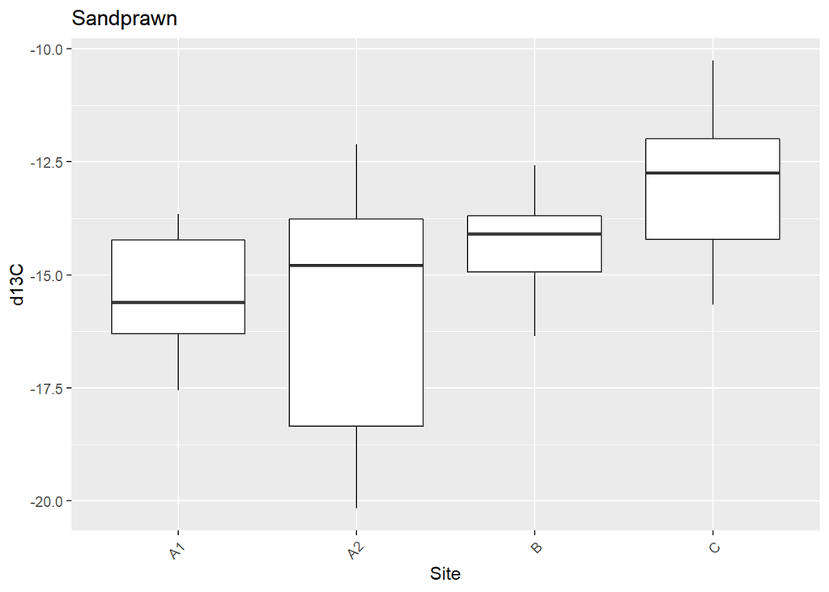

```r
p1 + ggtitle("Sandprawn")
```

```r
p2= ggplot(plants) +
    geom_boxplot(aes(y = d13C, x = Site)) +
    theme(axis.text.x = element_text(angle = 45, hjust = 1))
```

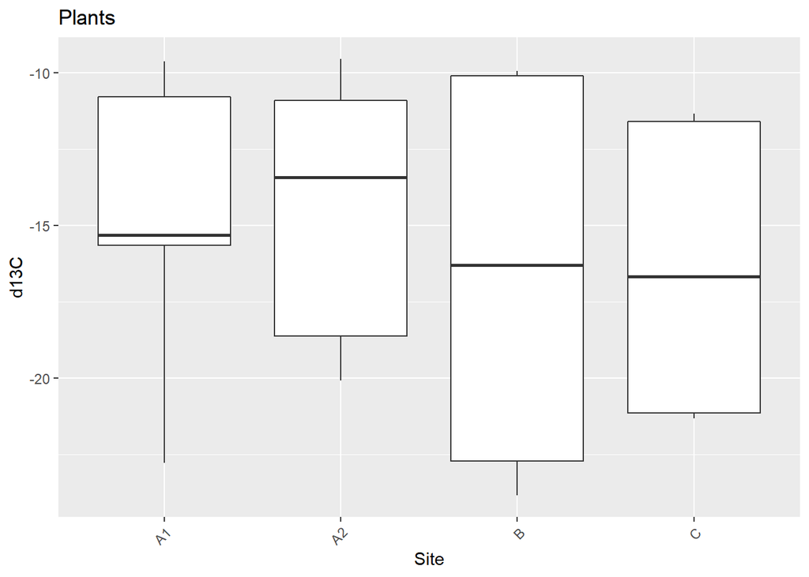

```r
p2 + ggtitle("Plants")
```

```r
p3= ggplot(sediment) +
    geom_boxplot(aes(y = d13C, x = Zone)) +
    theme(axis.text.x = element_text(angle = 45, hjust = 1))
```

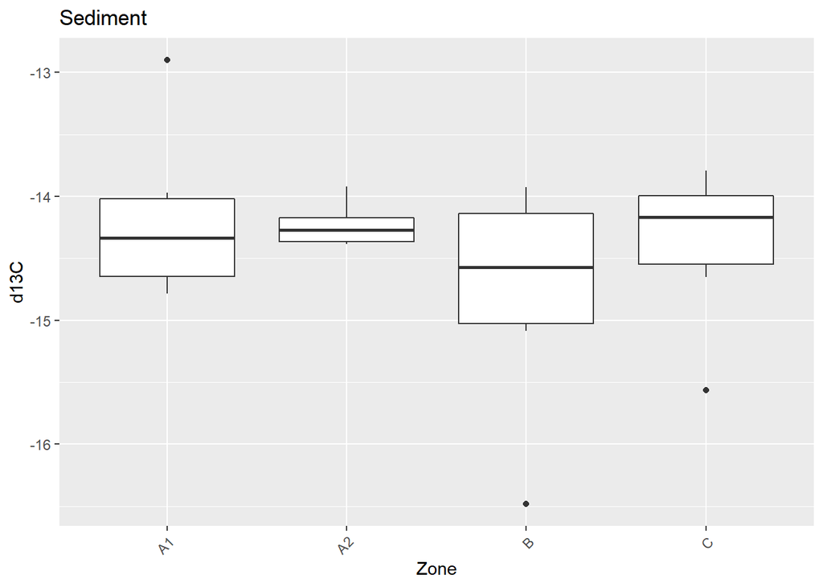

```r
p3 + ggtitle("Sediment")
```

```r
p4= ggplot(phyto) +
    geom_boxplot(aes(y = d13C, x = Site)) +
    theme(axis.text.x = element_text(angle = 45, hjust = 1))
```

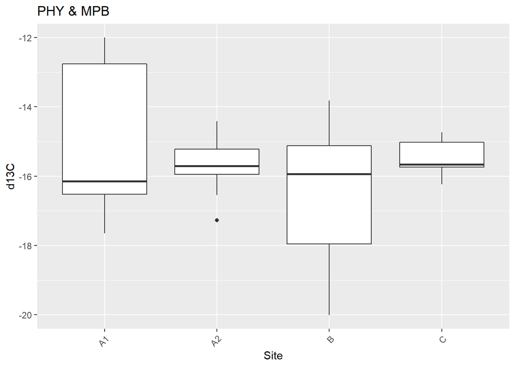

```r
p4 + ggtitle("PHY & MPB")
```

```r
p1.1= ggplot(SandprawnSelected) +
    geom_boxplot(aes(y = d15N, x = Site)) +
    theme(axis.text.x = element_text(angle = 45, hjust = 1))
```

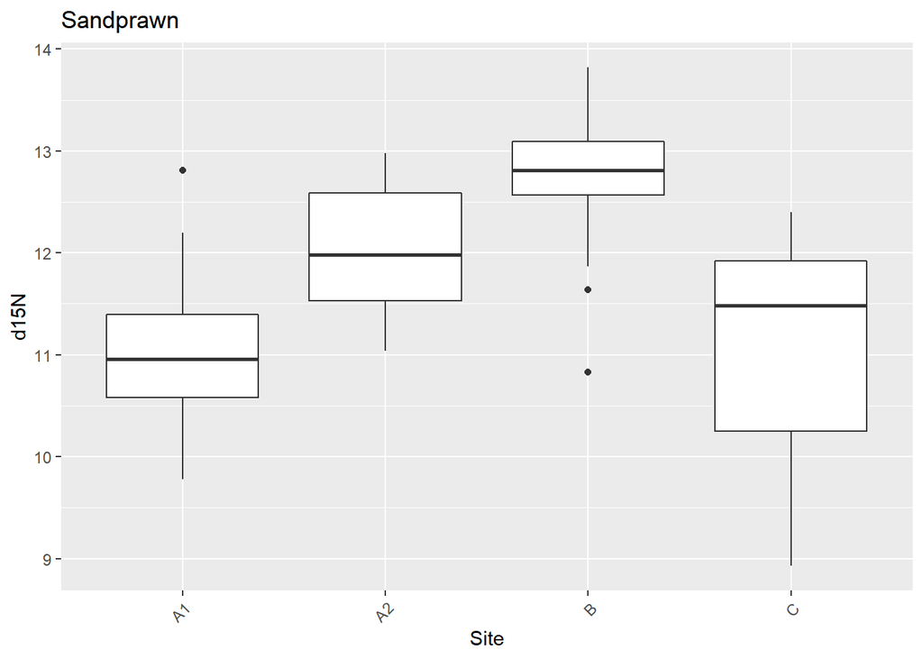

```r
p1.1 + ggtitle("Sandprawn")
```

```r
p2.1= ggplot(plants) +
    geom_boxplot(aes(y = d15N, x = Site)) +
    theme(axis.text.x = element_text(angle = 45, hjust = 1))
```

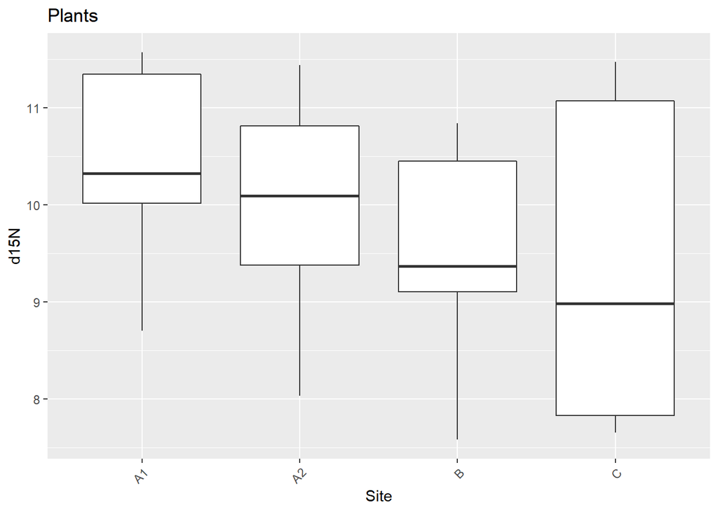

```r
p2.1 + ggtitle("Plants")
```

```r
p3.1= ggplot(sediment) +
    geom_boxplot(aes(y = d15N, x = Zone)) +
    theme(axis.text.x = element_text(angle = 45, hjust = 1))
```

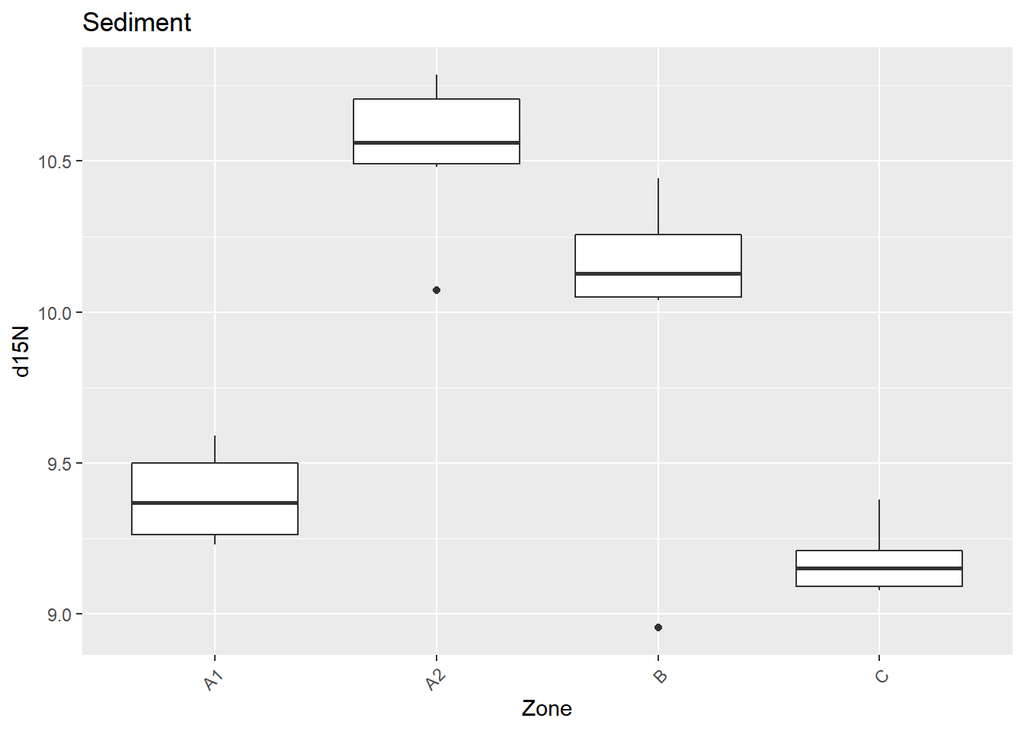

```r
p3.1 + ggtitle("Sediment")
```

```r
p4.1= ggplot(phyto) +
    geom_boxplot(aes(y = d15N, x = Site)) +
    theme(axis.text.x = element_text(angle = 45, hjust = 1))
```

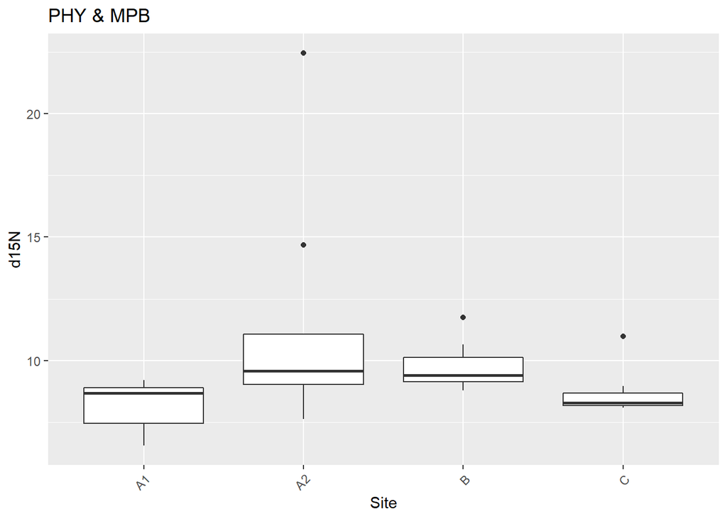

```r
p4.1 + ggtitle("PHY & MPB")
```